# An R Markdown document converted from “notebook.ipynb”

## 1. The most Nobel of Prizes

[figure not shown]

The Nobel Prize is perhaps the worlds most well known scientific award. Except for the honor, prestige and substantial prize money the recipient also gets a gold medal showing Alfred Nobel (1833 - 1896) who established the prize. Every year it’s given to scientists and scholars in the categories chemistry, literature, physics, physiology or medicine, economics, and peace. The first Nobel Prize was handed out in 1901, and at that time the Prize was very Eurocentric and male-focused, but nowadays it’s not biased in any way whatsoever. Surely. Right?

Well, we’re going to find out! The Nobel Foundation has made a dataset available of all prize winners from the start of the prize, in 1901, to 2016. Let’s load it in and take a look.

```r
# Loading in required libraries
# .... YOUR CODE FOR TASK 1 ....
library(tidyverse)
# Reading in the Nobel Prize data
nobel <- read_csv("datasets/nobel.csv")
# Taking a look at the first couple of winners
# .... YOUR CODE FOR TASK 1 ....
head(nobel)
```

```
## # A tibble: 6 × 18
##    year category   prize        motivation prize_share laureate_id laureate_type
##   <dbl> <chr>      <chr>        <chr>      <chr>             <dbl> <chr>
## 1  1901 Chemistry  The Nobel P… "\"in rec… 1/1                 160 Individual
## 2  1901 Literature The Nobel P… "\"in spe… 1/1                 569 Individual
## 3  1901 Medicine   The Nobel P… "\"for hi… 1/1                 293 Individual
## 4  1901 Peace      The Nobel P…  <NA>      1/2                 462 Individual
## 5  1901 Peace      The Nobel P…  <NA>      1/2                 463 Individual
## 6  1901 Physics    The Nobel P… "\"in rec… 1/1                   1 Individual
## # … with 11 more variables: full_name <chr>, birth_date <date>,
## #   birth_city <chr>, birth_country <chr>, sex <chr>, organization_name <chr>,
## #   organization_city <chr>, organization_country <chr>, death_date <date>,
## #   death_city <chr>, death_country <chr>
```

## 2. So, who gets the Nobel Prize?

Just looking at the first couple of prize winners, or Nobel laureates as they are also called, we already see a celebrity: Wilhelm Conrad Röntgen, the guy who discovered X-rays. And actually, we see that all of the winners in 1901 were guys that came from Europe. But that was back in 1901, looking at all winners in the dataset, from 1901 to 2016, which sex and which country is the most commonly represented?

(For *country*, we will use the `birth_country` of the winner, as the `organization_country` is `NA` for all shared Nobel Prizes.)

```r
# Counting the number of (possibly shared) Nobel Prizes handed
# out between 1901 and 2016
nobel %>% count()
```

```
## # A tibble: 1 × 1
##       n
##   <int>
## 1   911
```

```r
# Counting the number of prizes won by male and female recipients.
nobel %>%
  group_by(sex) %>%
  count()
```

```
## # A tibble: 3 × 2
## # Groups:   sex [3]
##   sex        n
##   <chr>  <int>
## 1 Female    49
## 2 Male     836
## 3 <NA>      26
```

```r
# Counting the number of prizes won by different nationalities.
nobel %>%
    group_by(birth_country) %>%
    count(sort = TRUE) %>%
    head(20)
```

```
## # A tibble: 20 × 2
## # Groups:   birth_country [20]
##    birth_country                n
##    <chr>                    <int>
##  1 United States of America   259
##  2 United Kingdom              85
##  3 Germany                     61
##  4 France                      51
##  5 Sweden                      29
##  6 <NA>                        26
##  7 Japan                       24
##  8 Canada                      18
##  9 Netherlands                 18
## 10 Italy                       17
## 11 Russia                      17
## 12 Switzerland                 16
## 13 Austria                     14
## 14 Norway                      12
## 15 China                       11
## 16 Denmark                     11
## 17 Australia                   10
## 18 Belgium                      9
## 19 Scotland                     9
## 20 South Africa                 9
```

## 3. USA dominance

Not so surprising perhaps: the most common Nobel laureate between 1901 and 2016 was a man born in the United States of America. But in 1901 all the laureates were European. When did the USA start to dominate the Nobel Prize charts?

```r
# Calculating the proportion of USA born winners per decade
prop_usa_winners <- nobel %>%
  mutate(usa_born_winner = birth_country == "United States of America") %>%
  mutate(decade = year - (year %% 10)) %>%
  group_by(decade) %>%
  summarize(proportion = mean(usa_born_winner, na.rm = TRUE))


# Display the proportions of USA born winners per decade
# .... YOUR CODE FOR TASK 3 ....
prop_usa_winners
```

```
## # A tibble: 12 × 2
##    decade proportion
##     <dbl>      <dbl>
##  1   1900     0.0179
##  2   1910     0.0789
##  3   1920     0.0741
##  4   1930     0.255
##  5   1940     0.325
##  6   1950     0.296
##  7   1960     0.28
##  8   1970     0.320
##  9   1980     0.330
## 10   1990     0.416
## 11   2000     0.437
## 12   2010     0.304
```

## 4. USA dominance, visualized

A table is OK, but to *see* when the USA started to dominate the Nobel charts we need a plot!

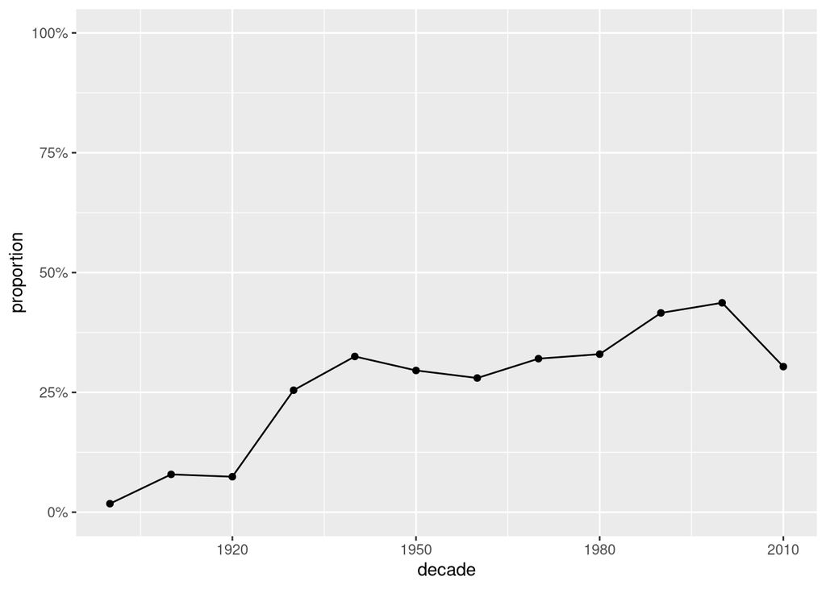

```r
# Setting the size of plots in this notebook
options(repr.plot.width=7, repr.plot.height=4)

# Plotting USA born winners
# .... YOUR CODE FOR TASK 4 ....

prop_usa_winners %>%
  ggplot(aes(x = decade, y = proportion)) +
  geom_line() +
  geom_point() +
  scale_y_continuous(labels = scales::percent, limits = c(0, 1))
```

## 5. What is the gender of a typical Nobel Prize winner?

So the USA became the dominating winner of the Nobel Prize first in the 1930s and has kept the leading position ever since. But one group that was in the lead from the start, and never seems to let go, are *men*. Maybe it shouldn’t come as a shock that there is some imbalance between how many male and female prize winners there are, but how significant is this imbalance? And is it better or worse within specific prize categories like physics, medicine, literature, etc.?

```r
# Calculating the proportion of female laureates per decade
prop_female_winners <- nobel %>%
  mutate(female_winner = sex == "Female") %>%
  mutate(decade = year - (year %% 10)) %>%
  group_by(decade, category) %>%
  summarize(proportion = mean(female_winner, na.rm = TRUE))
```

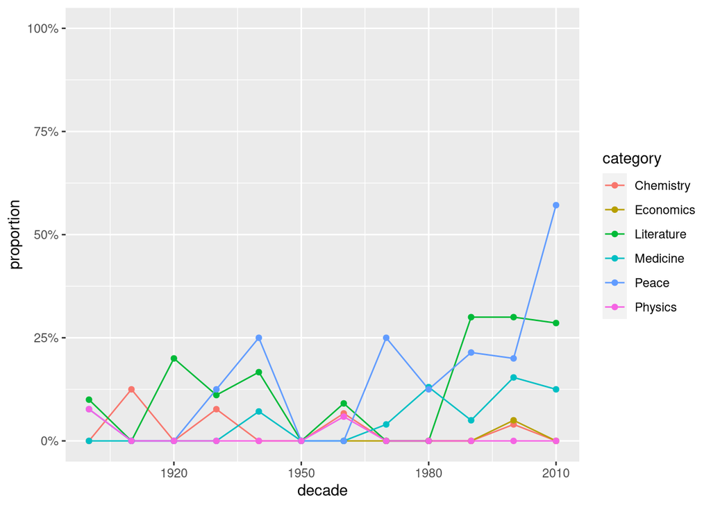

```r
# Plotting the proportion of female laureates per decade
# .... YOUR CODE FOR TASK 5 ....
prop_female_winners %>%
  ggplot(aes(x = decade, y = proportion, color = category)) +
  geom_line() +
  geom_point() +
#  geom_smooth() +
  scale_y_continuous(labels = scales::percent, limits = c(0, 1))
```

## 6. The first woman to win the Nobel Prize

The plot above is a bit messy as the lines are overplotting. But it does show some interesting trends and patterns. Overall the imbalance is pretty large with physics, economics, and chemistry having the largest imbalance. Medicine has a somewhat positive trend, and since the 1990s the literature prize is also now more balanced. The big outlier is the peace prize during the 2010s, but keep in mind that this just covers the years 2010 to 2016.

Given this imbalance, who was the first woman to receive a Nobel Prize? And in what category?

```r
# Picking out the first woman to win a Nobel Prize
nobel %>%
  filter(sex == "Female") %>%
  top_n(n = 1, wt = desc(year))
```

```
## # A tibble: 1 × 18
##    year category prize          motivation prize_share laureate_id laureate_type
##   <dbl> <chr>    <chr>          <chr>      <chr>             <dbl> <chr>
## 1  1903 Physics  The Nobel Pri… "\"in rec… 1/4                   6 Individual
## # … with 11 more variables: full_name <chr>, birth_date <date>,
## #   birth_city <chr>, birth_country <chr>, sex <chr>, organization_name <chr>,
## #   organization_city <chr>, organization_country <chr>, death_date <date>,
## #   death_city <chr>, death_country <chr>
```

## 7. Repeat laureates

For most scientists/writers/activists a Nobel Prize would be the crowning achievement of a long career. But for some people, one is just not enough, and there are few that have gotten it more than once. Who are these lucky few? (Having won no Nobel Prize myself, I’ll assume it’s just about luck.)

```r
# Selecting the laureates that have received 2 or more prizes.
nobel %>%
  count(full_name, sort = TRUE) %>%
  filter(n > 1)
```

```
## # A tibble: 6 × 2
##   full_name                                                                    n
##   <chr>                                                                    <int>
## 1 Comité international de la Croix Rouge (International Committee of the …     3
## 2 Frederick Sanger                                                             2
## 3 John Bardeen                                                                 2
## 4 Linus Carl Pauling                                                           2
## 5 Marie Curie, née Sklodowska                                                  2
## 6 Office of the United Nations High Commissioner for Refugees (UNHCR)          2
```

## 8. How old are you when you get the prize?

But how old are you generally when you get the prize?

```r
# Loading the lubridate package
# .... YOUR CODE FOR TASK 8 ....
library(lubridate)
```

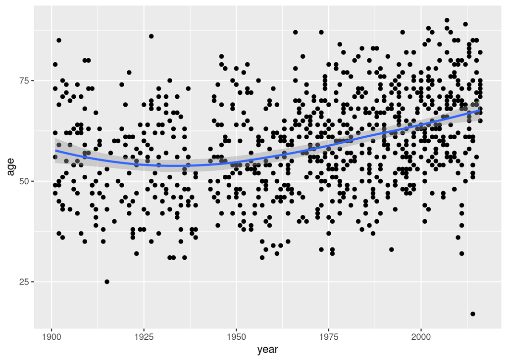

```r
# Calculating the age of Nobel Prize winners
nobel_age <- nobel %>%
    mutate(age = year - year(birth_date))

# Plotting the age of Nobel Prize winners
# .... YOUR CODE FOR TASK 8 ....

nobel_age %>%
  ggplot(aes(x = year, y = age)) +
  geom_point() +
  geom_smooth()
```

## 9. Age differences between prize categories

The plot above shows us a lot! We see that people use to be around 55 when they received the price, but nowadays the average is closer to 65. But there is a large spread in the laureates’ ages, and while most are 50+, some are very young.

We also see that the density of points is much high nowadays than in the early 1900s – nowadays many more of the prizes are shared, and so there are many more winners. We also see that there was a disruption in awarded prizes around the Second World War (1939 - 1945).

Let’s look at age trends within different prize categories.

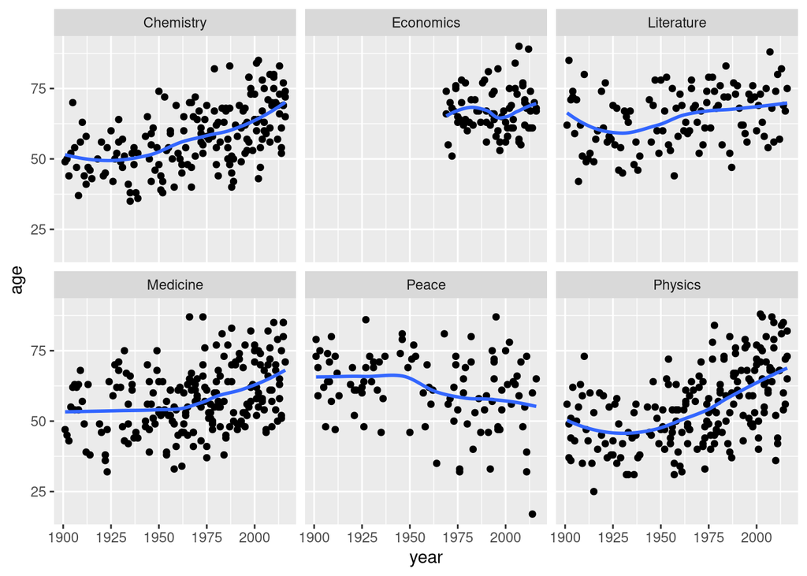

```r
# Same plot as above, but faceted by the category of the Nobel Prize
# .... YOUR CODE FOR TASK 9 ....

nobel_age %>%
  ggplot(aes(x = year, y = age)) +
  geom_point() +
  geom_smooth(se = FALSE) +
  facet_wrap(~ category)
```

## 10. Oldest and youngest winners

Another plot with lots of exciting stuff going on! We see that both winners of the chemistry, medicine, and physics prize have gotten older over time. The trend is strongest for physics: the average age used to be below 50, and now it’s almost 70. Literature and economics are more stable, and we also see that economics is a newer category. But peace shows an opposite trend where winners are getting younger!

In the peace category we also a winner around 2010 that seems exceptionally young. This begs the questions, who are the oldest and youngest people ever to have won a Nobel Prize?

```r
# The oldest winner of a Nobel Prize as of 2016
nobel_age %>% top_n(n = 1, wt = age)
```

```
## # A tibble: 1 × 19
##    year category  prize         motivation prize_share laureate_id laureate_type
##   <dbl> <chr>     <chr>         <chr>      <chr>             <dbl> <chr>
## 1  2007 Economics The Sveriges… "\"for ha… 1/3                 820 Individual
## # … with 12 more variables: full_name <chr>, birth_date <date>,
## #   birth_city <chr>, birth_country <chr>, sex <chr>, organization_name <chr>,
## #   organization_city <chr>, organization_country <chr>, death_date <date>,
## #   death_city <chr>, death_country <chr>, age <dbl>
```

```r
# The youngest winner of a Nobel Prize as of 2016
nobel_age %>% top_n(n = 1, wt = desc(age))
```

```
## # A tibble: 1 × 19
##    year category prize          motivation prize_share laureate_id laureate_type
##   <dbl> <chr>    <chr>          <chr>      <chr>             <dbl> <chr>
## 1  2014 Peace    The Nobel Pea… "\"for th… 1/2                 914 Individual
## # … with 12 more variables: full_name <chr>, birth_date <date>,
## #   birth_city <chr>, birth_country <chr>, sex <chr>, organization_name <chr>,
## #   organization_city <chr>, organization_country <chr>, death_date <date>,
## #   death_city <chr>, death_country <chr>, age <dbl>
```

## 11. You get a prize!

[figure not shown]

Hey! You get a prize for making it to the very end of this notebook! It might not be a Nobel Prize, but I made it myself in paint so it should count for something. But don’t despair, Leonid Hurwicz was 90 years old when he got his prize, so it might not be too late for you. Who knows.

Before you leave, what was again the name of the youngest winner ever who in 2014 got the prize for “[her] struggle against the suppression of children and young people and for the right of all children to education”?

```r
# The name of the youngest winner of the Nobel Prize as of 2016
youngest_winner <- "Malala Yousafzai"
```